# Tarea 10: Representación gráfica

Jhan Kevin

19/5/2020

### Cargar datos

Instala y carga el paquete `MASS`.

En el hay una tabla de datos llamada birthwt sobre factores que pueden incidir en el peso de los niños al nacer.

```r
#install.packages("MASS")
library(MASS)
df_baby <- birthwt
```

Utiliza `str()` y `head()` para explorar la estructura, y con `help()`, mirar el significado de cada variable.

```r
str(df_baby)
```

```
## 'data.frame':    189 obs. of  10 variables:
##  $ low  : int  0 0 0 0 0 0 0 0 0 0 ...
##  $ age  : int  19 33 20 21 18 21 22 17 29 26 ...
##  $ lwt  : int  182 155 105 108 107 124 118 103 123 113 ...
##  $ race : int  2 3 1 1 1 3 1 3 1 1 ...
##  $ smoke: int  0 0 1 1 1 0 0 0 1 1 ...
##  $ ptl  : int  0 0 0 0 0 0 0 0 0 0 ...
##  $ ht   : int  0 0 0 0 0 0 0 0 0 0 ...
##  $ ui   : int  1 0 0 1 1 0 0 0 0 0 ...
##  $ ftv  : int  0 3 1 2 0 0 1 1 1 0 ...
##  $ bwt  : int  2523 2551 2557 2594 2600 2622 2637 2637 2663 2665 ...
```

```r
head(df_baby)
```

```
##    low age lwt race smoke ptl ht ui ftv  bwt
## 85   0  19 182    2     0   0  0  1   0 2523
## 86   0  33 155    3     0   0  0  0   3 2551
## 87   0  20 105    1     1   0  0  0   1 2557
## 88   0  21 108    1     1   0  0  1   2 2594
## 89   0  18 107    1     1   0  0  1   0 2600
## 91   0  21 124    3     0   0  0  0   0 2622
```

```r
#?birthwt
```

### 1. Calcula una tabla de frecuencias relativas marginales de los pares (raza de la madre, peso inferior a 2.5 kg o no) que permita ver si la raza de la madre influye en el peso del bebé.

```r
raza <- factor(df_baby$race, labels = c('Blanca','Nigga','Otro'))
menos25 <- factor(df_baby$low, labels = c('No','Si'))

tb1 <- ftable(raza, menos25)
```

La tabla de frecuencias relativas debe ser dicriminando la raza, la cual es

```r
round(prop.table(tb1, margin = 1),1)
```

```
##        menos25  No  Si
## raza
## Blanca         0.8 0.2
## Nigga          0.6 0.4
## Otro           0.6 0.4
```

### 2. Dibuja un diagrama de mosaico de la tabla del ejercicio anterior.

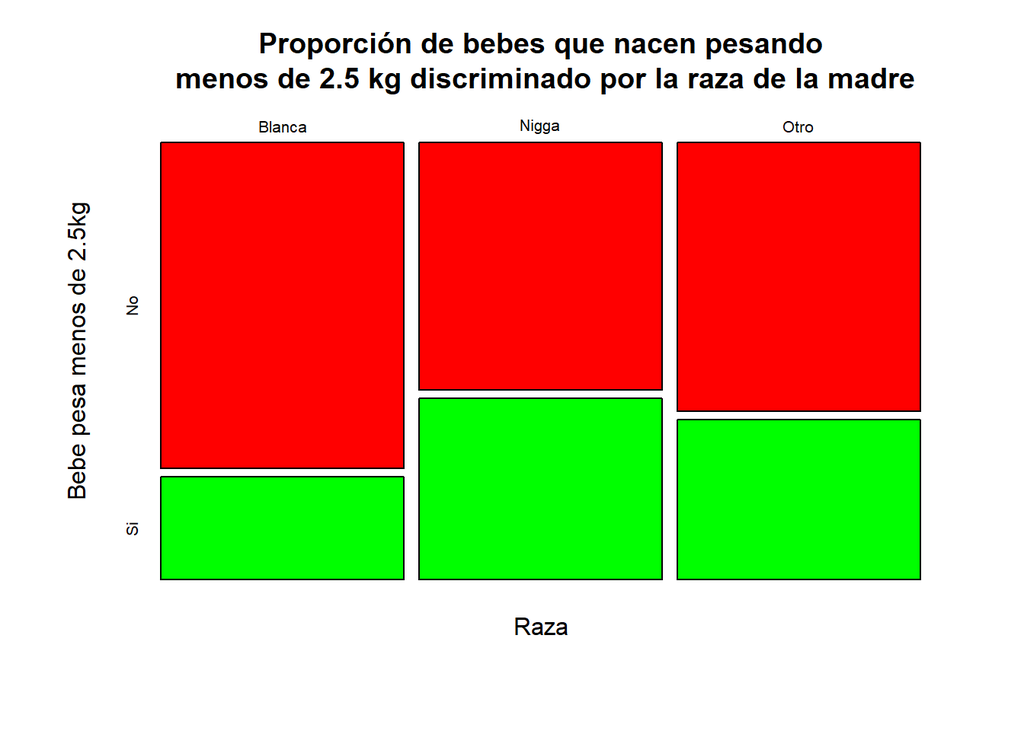

```r
mosaicplot(prop.table(table(raza, menos25), margin = 1),
           main = 'Proporción de bebes que nacen pesando\n menos de 2.5 kg discriminado por la raza de la madre',
           xlab = 'Raza', ylab = 'Bebe pesa menos de 2.5kg',
           color = c('red','green'))
```

Si dentro de la función `mosaicplot()` se usa la tabla `tb1` creada anteriormente con `ftable()`, se tendrá un error con las etiquetas. Por lo cual para realizar la grafica se debe utilizar `table()`.

### 3. Dibuja un diagrama bidimensional de barras, con las barras organizadas en bloques, que permita visualizar la información de los ejercicios anteriores. Aprovecha para nombres adecuados a los bloques, colores a las barras, y añadir una leyenda que explique qué representa cada barra.

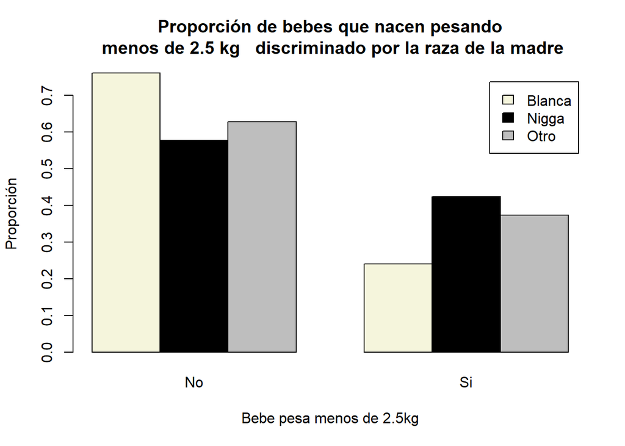

```r
barplot(prop.table(table(raza, menos25), margin = 1),
        beside = TRUE, legend.text = TRUE,
        main = 'Proporción de bebes que nacen pesando\n menos de 2.5 kg   discriminado por la raza de la madre',
        xlab = 'Bebe pesa menos de 2.5kg', ylab = 'Proporción',
        col = c('beige','black','gray'))
```

### 4. ¿Se puede obtener alguna conclusión de la tabla y el diagrama de barras anterior? Argumenta tu respuesta

Según los datos, la raza de la madre si influye en el peso del recién nacido. COntrastan la raza blanca y el resto, teniendo menos proporción de recién nacidos con peso por debajo de los 2.5 kg en el primer caso.

### 6. Calcula una tabla de frecuencias relativas marginales de las ternas (raza de la madre, madre fumadora o no, peso inferior a 2.5 kg o no) que permita ver si la raza de la madre y su condición de fumadora o no fumadora influyen en el peso del bebé.

```r
fuma <- factor(df_baby$smoke, labels = c('No','Si'))

round(prop.table(table(raza,fuma,menos25), margin = c(1,2)),2)
```

```
## , , menos25 = No
##
##         fuma
## raza       No   Si
##   Blanca 0.91 0.63
##   Nigga  0.69 0.40
##   Otro   0.64 0.58
##
## , , menos25 = Si
##
##         fuma
## raza       No   Si
##   Blanca 0.09 0.37
##   Nigga  0.31 0.60
##   Otro   0.36 0.42
```

### 7. Dibuja un diagrama de mosaico de la tabla del ejercicio anterior.

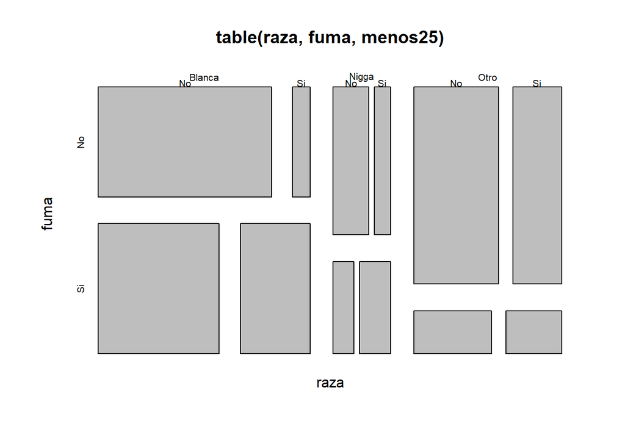

```r
mosaicplot(table(raza,fuma,menos25))
```